# Distribution of k-1 smallest random variables

Use `sample_growth_tb` to compare distributions of minimum annual growth rates between firms with high growth over 2010–2020 (HGF) and all others (non-HGF). Use ten-year growth to identify high-growth firms.

## 0 Data preparation

```r
library(tidyverse)
library(pins)
library(hrbrthemes)
theme_set(theme_ipsum(base_size = 12, axis_title_size = 13))
board <- board_folder("../Zipf_law_board_replicate_simulation")
```

Load `sample_growth_tb` and extract ten annual growth rates from 2010–11 through 2019–20 and growth over 2010–2020 (`g_20_10`). Select firms meeting the following conditions.

- Beginning-of-period sales in 2010 of at least $4.0\times10^4$  
  With sales measured in thousands of yen, this corresponds to at least 40 million yen.
- Establishment year of 2005 or earlier This corresponds to firm age of at least five, measured as 2010 minus the establishment year.
- The first two digits of the reference-period industry code are 01–61 or 68–92

Do not impose additional restrictions based on sales, age, or industry in other periods.

```r
library(matrixStats)

sample_growth_tb <- board |> pin_read("sample_growth_tb", type = "qs2") |>
  filter(year %in% c("g_20_19", "g_19_18", "g_18_17", "g_17_16", "g_16_15",
                     "g_15_14", "g_14_13", "g_13_12", "g_12_11", "g_11_10",
                     "g_20_10"))

growth_wide_tb <- sample_growth_tb |>
  pivot_wider(id_cols = id, names_from = year, values_from = growth) |>
  left_join(sample_growth_tb |> filter(year == "g_11_10") |> select(id, pre_sale, birth_year, ind_class), by = "id") |>
  filter(pre_sale >= 4.0*10^{4},
         birth_year <= 2005,
         str_sub(ind_class, 1,2) %in% str_pad(c(1:61, 68:92), 2, pad = 0)) |>
  na.omit() |>
  select(-pre_sale, -birth_year, -ind_class)
```

## 1 Comparing minimum growth rates

**Checking upper percentiles**

Using `growth_wide_tb` after sample selection and removal of missing values, inspect the 90th, 95th, 97th, and 99th percentiles of ten-year growth `g_20_10`. Use the 97th percentile of this full sample for the subsequent high-growth classification.

```r
growth_wide_tb |>
  summarise(q_90 = quantile(g_20_10, 0.90, na.rm = T),
            q_95 = quantile(g_20_10, 0.95, na.rm = T),
            q_97 = quantile(g_20_10, 0.97, na.rm = T),
            q_99 = quantile(g_20_10, 0.99, na.rm = T))
```

| q_90 | q_95 | q_97 | q_99 |
| --- | --- | --- | --- |
| 0.7921235 | 1.123621 | 1.377241 | 1.955478 |

**Creating `compare_smallest_tb` to store minimum growth rates**

Classify firms whose `g_20_10` is strictly above the 97th percentile as HGF and all others as non-HGF, adding the indicator `hg`.

The function `add_smallest()` converts the specified growth columns to a matrix, calculates each firm’s minimum using `rowOrderStats(..., which = 1)`, and stores it in `smallest_1st`. Use the following periods for each group.

- non-HGF: nine periods from 2010–11 through 2018–19 (`g_19_18:g_11_10`)
- HGF: ten periods from 2010–11 through 2019–20 (`g_20_19:g_11_10`)

```r
temp_tb <- growth_wide_tb |>
  mutate(hg = if_else(g_20_10 > quantile(g_20_10, 0.97, na.rm = T), "HGF", "non-HGF"))

add_smallest <- function(df, growth_cols) {
  growth_matrix <- df |>
    select(all_of(growth_cols)) |>
    as.matrix()

  df |> mutate(smallest_1st = rowOrderStats(growth_matrix, which = 1))
}

compare_smallest_tb <-
  bind_rows(
    temp_tb |>
      filter(hg == "non-HGF") |>
      add_smallest(names(select(temp_tb, g_19_18:g_11_10))),
    temp_tb |>
      filter(hg == "HGF") |>
      add_smallest(names(select(temp_tb, g_20_19:g_11_10)))
  )
```

**Visual comparison of distributions**

Compare densities of minimum growth `smallest_1st` between HGF and non-HGF. Restrict only the displayed horizontal range to −1.5–1.5.

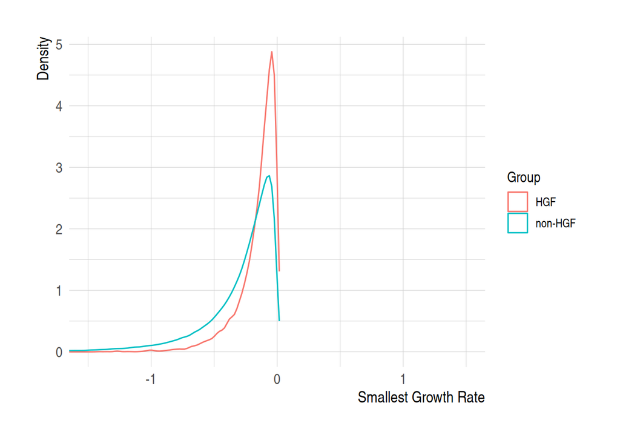

```r
compare_smallest_tb |>
ggplot() +
  geom_density(aes(smallest_1st, color = hg)) +
  coord_cartesian(xlim = c(-1.5,1.5)) +
  labs(
    x = "Smallest Growth Rate",
    y = "Density",
    color = "Group"
  ) +
  theme(axis.title = element_text(face = "bold"))
ggsave(filename = "compare_smallest_growth.png", path = "graph")
```

```r
compare_smallest_tb |>
  group_by(hg) |>
  summarise(median(smallest_1st), mean(smallest_1st), n_obs = n())
```

| hg | median(smallest_1st) | mean(smallest_1st) | n_obs |
| --- | --- | --- | --- |
| HGF | -0.1037117 | -0.1528807 | 5393 |
| non-HGF | -0.1981044 | -0.3017121 | 174344 |